# Assignment3MSaunders

Meg_Saunders

05/12/2020

```r
#package installations for assignment/textbook examples
library(tidyverse)
library(dplyr)
library(tidyverse)
library(sf)
library(tigris)
library(leaflet)
library(censusapi)
library(corrplot)
```

Exreme Commuting in the Bay Area: The Bay Area Equity Atlas has flagged extreme commuting (commutes to work that take 90 minutes or longer) as a significant problem in the bay area, where certain groups of people are disproportionately represented as being subjected to extreme commutes. The article linked here (https://bayareaequityatlas.org/indicators/extreme-commuting#/) makes the following claims about extreme commuting in the bay area: - Black workers are more likely than workers of other races to have to make extreme commutes to get to work. - Black women in particular are likely to have extreme commuting times. - Low income communities in particular are likely to have extreme commuting times because they rely on underfunded public transportation systems. - Out of the 9 bay area counties, Contra Costa and Solano Counties have the highest rates of extreme commuting. - Out of the 9 bay area counties, Santa Clara and San Mateo have the lowest rates of extreme commuting.

```r
Sys.setenv(CENSUS_KEY="d8acd392d4fdb8cfbe2e6c8369ed38ae1ba5f4d0")
library(tidycensus)
```

```r
chooseCRANmirror(graphics=FALSE, ind=1)
install.packages("devtools")
devtools::install_github("walkerke/tidycensus")
library(tidycensus)
census_api_key("d8acd392d4fdb8cfbe2e6c8369ed38ae1ba5f4d0")
```

Analysis at the PUMA level. Outcome: Time it takes to travel to work Independent Variables: 1. Income 2. Percent Black #TODO Analysis at the Tract Level Outcome: Time it takes to travel to work Independent Variables: 1. Percent Black 2. Income level

```r
acs_vars_2018_5yr <-
  listCensusMetadata(
    name = "2018/acs/acs5",
    type = "variables"
  )
```

```r
acs_vars_2013_5yr <-
  listCensusMetadata(
    name = "2013/acs/acs5",
    type = "variables"
  )
```

```r
bay_tt_employed_tract_18 <-
  getCensus(
    name = "acs/acs5",
    vintage = 2018,
    region = "tract:*",
    regionin = "state:06+county:001,013,041,055,075,081,085,095,097",
    vars = c(
      "B08303_001E",
      "B08303_012E",
      "B08303_013E",
      "C23002B_012E",
      "C23002B_007E",
      "C23002B_020E",
      "C23002B_025E",
      "C18120_003E",
      "B17005_010E",
      "B17005_005E",
      "B17005_021E",
      "B17005_016E",
      "C23002A_012E",
      "C23002A_025E",
      "C23002C_012E",
      "C23002C_025E",
      "C23002D_012E",
      "C23002D_025E",
      "C23002E_012E",
      "C23002E_025E",
      "C23002F_012E",
      "C23002F_025E",
      "C23002G_012E",
      "C23002G_025E",
      "B19001_001E", #Total
      "B19001_002E", #<10k
      "B19001_003E",
      "B19001_004E",
      "B19001_005E",
      "B19001_006E",
      "B19001_007E",
      "B19001_008E",
      "B19001_009E",
      "B19001_010E",
      "B19001_011E",
      "B19001_012E",
      "B19001_013E",
      "B19001B_001E"
    )
  ) %>%
  transmute(
    tract = paste0(state, county, tract),
    perc_extreme = B08303_013E/B08303_001E,
    total_employed_black = C23002B_012E + C23002B_007E + C23002B_020E + C23002B_025E,
    total_employed_black_women = C23002B_020E + C23002B_025E,
    total_employed = C18120_003E,
    perc_employed_black = (total_employed_black/total_employed),
    perc_employed_black_women = (total_employed_black_women/total_employed),
    total_employed_B17005 = B17005_021E + B17005_010E + B17005_016E + B17005_005E,
    total_employed_below_poverty = B17005_010E + B17005_005E,
    perc_employed_below_poverty = (total_employed_below_poverty/total_employed_B17005),
    perc_under_100k = (B19001_002E + B19001_003E + B19001_004E + B19001_005E + B19001_006E + B19001_007E + B19001_008E + B19001_009E + B19001_010E + B19001_011E + B19001_012E + B19001_013E)/B19001_001E,
    perc_under_50k = (B19001_002E + B19001_003E + B19001_004E + B19001_005E + B19001_006E + B19001_007E + B19001_008E + B19001_009E + B19001_010E)/B19001_001E,
    perc_10_to_100 = (B19001_003E + B19001_004E + B19001_005E + B19001_006E + B19001_007E + B19001_008E + B19001_009E + B19001_010E + B19001_011E + B19001_012E + B19001_013E)/B19001_001E
  ) %>%
  filter(
    !is.na(perc_under_100k),
    !is.na(perc_10_to_100),
    !is.na(perc_extreme),
    !is.na(perc_employed_black),
    !is.na(perc_employed_below_poverty),
    !is.na(perc_employed_black_women)
  )
```

The following correlation plot displays the r-coefficients for the relationships that all these variables have to each other. The relations of interest - highlighted in orange - are those that pair the percentage of extreme commutes (the outcome of interest) with each of the other variables (the independent variables).

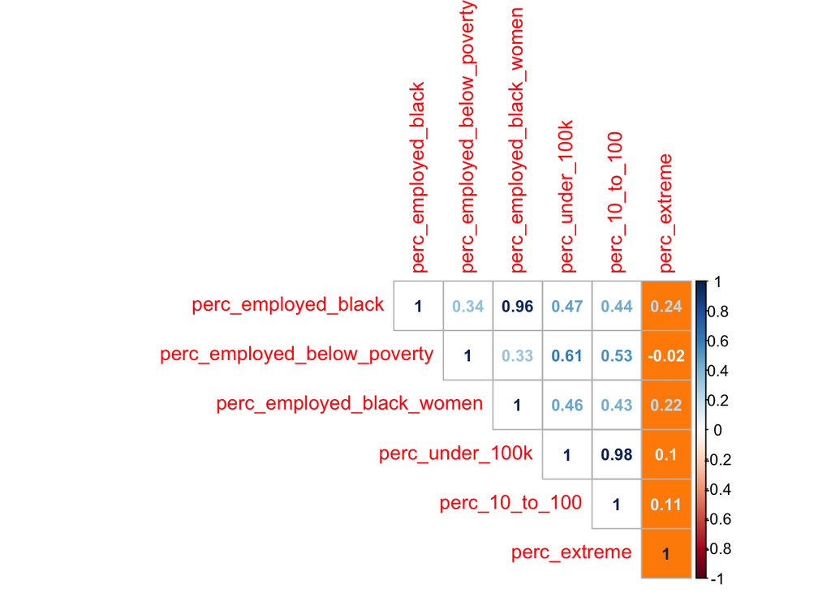

```r
corr_plot_tt_tract_18 <-
  bay_tt_employed_tract_18 %>%
  select(
    perc_employed_black,
    perc_employed_below_poverty,
    perc_employed_black_women,
    perc_under_100k,
    perc_10_to_100,
    perc_extreme
  ) %>%
  cor()

ColorScheme = c("white","darkorange")
Groups = c(rep(1, 15), rep(2, 6))
corrplot(
  corr_plot_tt_tract_18,
  method = "number",
  type = "upper",
  bg=ColorScheme[Groups],
  number.cex= 5/ncol(corr_plot_tt_tract_18)
)

segments(c(0.5,5.5,6.5), rep(0.5,1),
    c(0.5,5.5,6.5), rep(5.5,6), lwd=0)
```

Next, each variable’s relationship with the percentage of extreme work commutes will be represented as a scatter plot and summarized. Low Income Communities: To test whether low income communities are indeed more likely to have a higher percentage of extreme work commutes, the percentage of households earning less than $100,000 is plotted against the percentage of extreme work commutes. Here are the results:

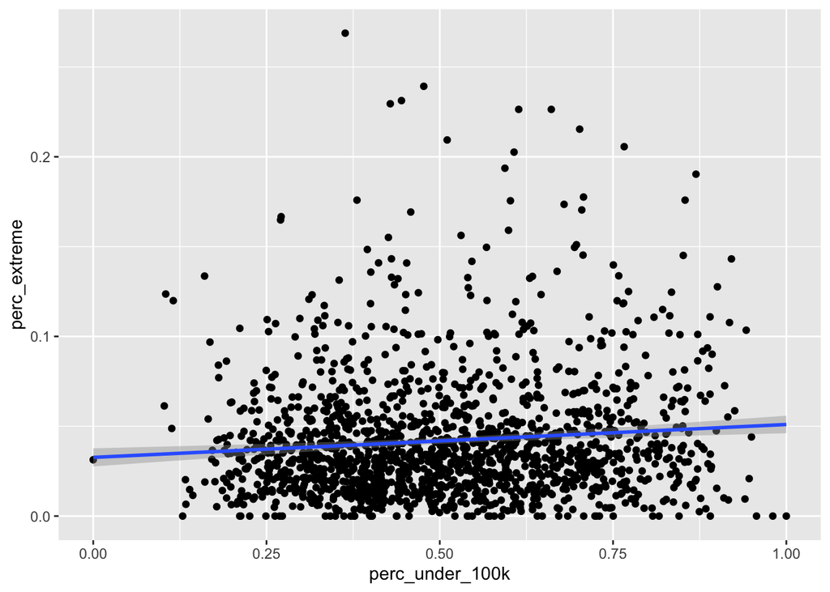

```r
ggplot(
  data = bay_tt_employed_tract_18,
  aes(
      x = perc_under_100k,
      y = perc_extreme
    )
) +
  geom_point() +
  geom_smooth(method = "lm")
```

```r
under100_extreme_model <- lm(perc_extreme ~ perc_under_100k, bay_tt_employed_tract_18)

summary(under100_extreme_model)
```

```
##
## Call:
## lm(formula = perc_extreme ~ perc_under_100k, data = bay_tt_employed_tract_18)
##
## Residuals:
##       Min        1Q    Median        3Q       Max
## -0.050974 -0.022426 -0.008196  0.011185  0.229500
##
## Coefficients:
##                 Estimate Std. Error t value Pr(>|t|)
## (Intercept)     0.032667   0.002576  12.682  < 2e-16 ***
## perc_under_100k 0.018307   0.004760   3.846 0.000125 ***
## ---
## Signif. codes:  0 '***' 0.001 '**' 0.01 '*' 0.05 '.' 0.1 ' ' 1
##
## Residual standard error: 0.03442 on 1575 degrees of freedom
## Multiple R-squared:  0.009302,   Adjusted R-squared:  0.008673
## F-statistic: 14.79 on 1 and 1575 DF,  p-value: 0.000125
```

Racial Disparities: The next variable plotted against the percentage of extreme commute times is the percentage of employed people who are black (perc_employed_black). A plot of the regression line is shown in the scatter plot below.

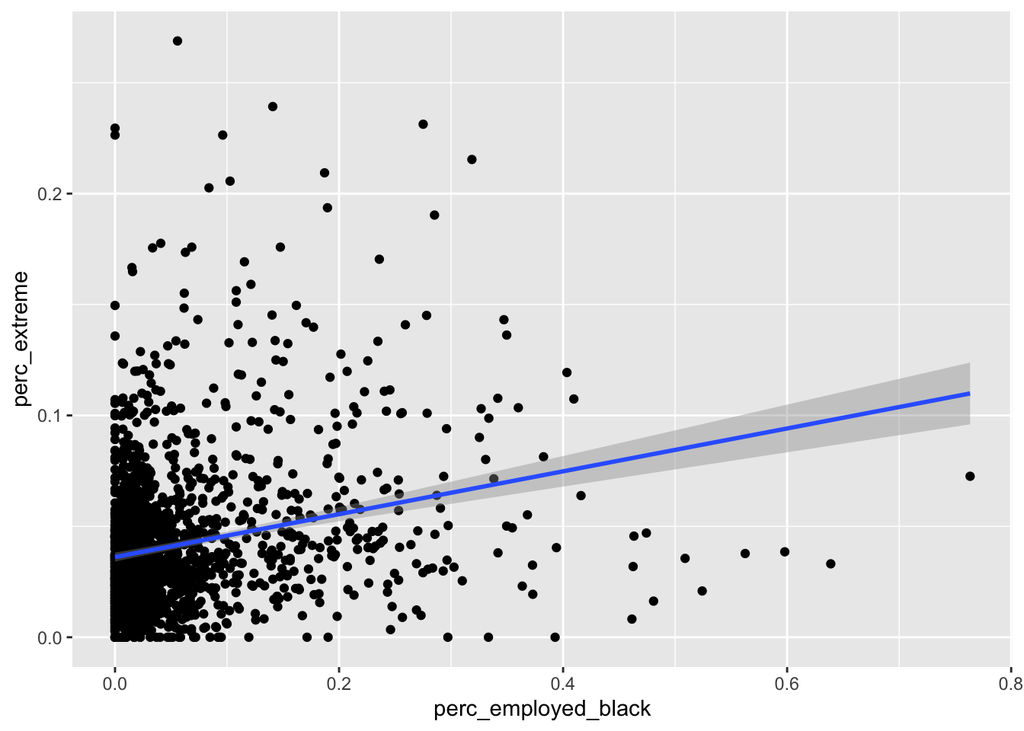

```r
ggplot(
  data = bay_tt_employed_tract_18,
  aes(
      x = perc_employed_black,
      y = perc_extreme
    )
) +
  geom_point() +
  geom_smooth(method = "lm")
```

Nevertheless, the observed correlation can be construed as deeply problematic given that extreme travel times diminish quality of life in the ways discussed above, and that these results suggest that this form of reduced quality of life is associated with a particular race.

```r
black_employed_extreme_model <- lm(perc_extreme ~ perc_employed_black, bay_tt_employed_tract_18)

summary(black_employed_extreme_model)
```

```
##
## Call:
## lm(formula = perc_extreme ~ perc_employed_black, data = bay_tt_employed_tract_18)
##
## Residuals:
##       Min        1Q    Median        3Q       Max
## -0.074105 -0.021502 -0.007562  0.011822  0.227288
##
## Coefficients:
##                     Estimate Std. Error t value Pr(>|t|)
## (Intercept)         0.036144   0.001042  34.694   <2e-16 ***
## perc_employed_black 0.096629   0.010035   9.629   <2e-16 ***
## ---
## Signif. codes:  0 '***' 0.001 '**' 0.01 '*' 0.05 '.' 0.1 ' ' 1
##
## Residual standard error: 0.0336 on 1575 degrees of freedom
## Multiple R-squared:  0.0556, Adjusted R-squared:  0.055
## F-statistic: 92.72 on 1 and 1575 DF,  p-value: < 2.2e-16
```

The next summary illustrates the relationship between the percentage of working people who are black AND the percentage of households earning less than $100,000 (as independent variables) on the percentage of extreme (90 mins plus) travel to work times.

Some key results of this multiple regression summary include the coefficient for perc_under_100k of -0.003513. This result is close to 0 which contrasts with the coefficient observed in the two variable regression of perc_under_100k and perc_extreme which was around 0.018307. Further, the p-value is for this coefficient is around 0.5 which means that the correlation between the percentage of households with an income under $100,000 and the percentage of extreme commute times is no longer statistically significant. What this suggests is when controlling for the percentage of employed people who are Black, there is no association between household incomes under 100k and extreme travel to work times. Both the degree and certainty to which perc_employed_black and perc_extreme are correlated when controlled for household incomes remain much the same, if not ever so slightly increased.

```r
black_and_under100k_model <- lm(perc_extreme ~ perc_employed_black + perc_under_100k, bay_tt_employed_tract_18)

summary(black_and_under100k_model)
```

```
##
## Call:
## lm(formula = perc_extreme ~ perc_employed_black + perc_under_100k,
##     data = bay_tt_employed_tract_18)
##
## Residuals:
##       Min        1Q    Median        3Q       Max
## -0.073568 -0.021342 -0.007743  0.011576  0.226792
##
## Coefficients:
##                      Estimate Std. Error t value Pr(>|t|)
## (Intercept)          0.037718   0.002580  14.620   <2e-16 ***
## perc_employed_black  0.100195   0.011372   8.811   <2e-16 ***
## perc_under_100k     -0.003513   0.005267  -0.667    0.505
## ---
## Signif. codes:  0 '***' 0.001 '**' 0.01 '*' 0.05 '.' 0.1 ' ' 1
##
## Residual standard error: 0.03361 on 1574 degrees of freedom
## Multiple R-squared:  0.05587,    Adjusted R-squared:  0.05467
## F-statistic: 46.57 on 2 and 1574 DF,  p-value: < 2.2e-16
```

The summary below includes the same multiple regression as above but with one added variable: the percentage of employed people who are black women. It is this group that was suggested by the article as particularly suffering from extreme commute to work times. However, it appears from the “perc_employed_black_women” coefficient of -0.013460 and the high p-value of 0.81722 that there is almost no association (controlled for income and the percentage of black people employed) between the percentage of specifically black women employed and extreme commute times. If anything, the association is very weakly negative. Therefore, whereas there is undoubtedly a problematic correlatoin between black working people and extreme commute times, this correlation does not apply specifically to black women.

These results so far are deeply troubling because they suggest that Black workers in general experience longer commute times for reasons that beyond lack of access to transportation options due to income. It is important to note that these results do not imply a causal relationship between being a black worker and having a longer travel to work time. Rather, there may well be another variable with a direct causal relationship with travel to work times which may also be associated with Black workers. Further, the relatively low percentage of around 6% of the variation in perc_extreme which can be explained by the variables analysed indicate that further analysis is needed to fully understand associations with extreme travel to work times.

```r
black_and_under100k_model_ww <- lm(perc_extreme ~ perc_employed_black + perc_under_100k + perc_employed_black_women, bay_tt_employed_tract_18)

summary(black_and_under100k_model_ww)
```

```
##
## Call:
## lm(formula = perc_extreme ~ perc_employed_black + perc_under_100k +
##     perc_employed_black_women, data = bay_tt_employed_tract_18)
##
## Residuals:
##       Min        1Q    Median        3Q       Max
## -0.074560 -0.021406 -0.007702  0.011634  0.226683
##
## Coefficients:
##                            Estimate Std. Error t value Pr(>|t|)
## (Intercept)                0.037666   0.002590  14.540  < 2e-16 ***
## perc_employed_black        0.107670   0.034279   3.141  0.00172 **
## perc_under_100k           -0.003482   0.005270  -0.661  0.50891
## perc_employed_black_women -0.013460   0.058228  -0.231  0.81722
## ---
## Signif. codes:  0 '***' 0.001 '**' 0.01 '*' 0.05 '.' 0.1 ' ' 1
##
## Residual standard error: 0.03362 on 1573 degrees of freedom
## Multiple R-squared:  0.0559, Adjusted R-squared:  0.0541
## F-statistic: 31.04 on 3 and 1573 DF,  p-value: < 2.2e-16
```

This next section runs the same multiple regression analysis on the previous 5 year block (2009-2013) to assess how exteme travel times have changed.

```r
bay_tt_employed_tract_13 <-
  getCensus(
    name = "acs/acs5",
    vintage = 2013,
    region = "tract:*",
    regionin = "state:06+county:001,013,041,055,075,081,085,095,097",
    vars = c(
      "B08303_001E",
      "B08303_012E",
      "B08303_013E",
      "C23002B_012E",
      "C23002B_007E",
      "C23002B_020E",
      "C23002B_025E",
      "C18120_003E",
      "B17005_010E",
      "B17005_005E",
      "B17005_021E",
      "B17005_016E",
      "C23002A_012E",
      "C23002A_025E",
      "C23002C_012E",
      "C23002C_025E",
      "C23002D_012E",
      "C23002D_025E",
      "C23002E_012E",
      "C23002E_025E",
      "C23002F_012E",
      "C23002F_025E",
      "C23002G_012E",
      "C23002G_025E",
      "B19001_001E", #Total
      "B19001_002E", #<10k
      "B19001_003E",
      "B19001_004E",
      "B19001_005E",
      "B19001_006E",
      "B19001_007E",
      "B19001_008E",
      "B19001_009E",
      "B19001_010E",
      "B19001_011E",
      "B19001_012E",
      "B19001_013E",
      "B19001B_001E"
    )
  ) %>%
  transmute(
    tract = paste0(state, county, tract),
    perc_extreme = B08303_013E/B08303_001E,
    total_employed_black = C23002B_012E + C23002B_007E + C23002B_020E + C23002B_025E,
    total_employed_black_women = C23002B_020E + C23002B_025E,
    total_employed = C18120_003E,
    perc_employed_black = (total_employed_black/total_employed),
    perc_employed_black_women = (total_employed_black_women/total_employed),
    total_employed_B17005 = B17005_021E + B17005_010E + B17005_016E + B17005_005E,
    total_employed_below_poverty = B17005_010E + B17005_005E,
    perc_employed_below_poverty = (total_employed_below_poverty/total_employed_B17005),
    perc_under_100k = (B19001_002E + B19001_003E + B19001_004E + B19001_005E + B19001_006E + B19001_007E + B19001_008E + B19001_009E + B19001_010E + B19001_011E + B19001_012E + B19001_013E)/B19001_001E,
    perc_under_50k = (B19001_002E + B19001_003E + B19001_004E + B19001_005E + B19001_006E + B19001_007E + B19001_008E + B19001_009E + B19001_010E)/B19001_001E,
    perc_10_to_100 = (B19001_003E + B19001_004E + B19001_005E + B19001_006E + B19001_007E + B19001_008E + B19001_009E + B19001_010E + B19001_011E + B19001_012E + B19001_013E)/B19001_001E
  ) %>%
  filter(
    !is.na(perc_under_100k),
    !is.na(perc_10_to_100),
    !is.na(perc_extreme),
    !is.na(perc_employed_black),
    !is.na(perc_employed_below_poverty),
    !is.na(perc_employed_black_women)
  )
```

The most notable difference between the results of the multiple regression analysis from the years 2009 to 2013 can be observed through the Coefficients. Whereas the subsequent 5 year block from 2014-2018 suggests a statistically significant correlation between black employed people and extreme travel times, the corresponding coefficient in these results (0.042484, with a p-value of 0.0679) indicate much less of an effect of the race of workers on travel times. This concerningly suggests that areas with higher percentages of Black employed people have more recently become disproportionately effected by extreme commute times pointing to widening racial inequalities in the bay area.

```r
black_and_under100k_model_ww_13 <- lm(perc_extreme ~ perc_employed_black + perc_under_100k + perc_employed_black_women, bay_tt_employed_tract_13)

summary(black_and_under100k_model_ww_13)
```

```
##
## Call:
## lm(formula = perc_extreme ~ perc_employed_black + perc_under_100k +
##     perc_employed_black_women, data = bay_tt_employed_tract_13)
##
## Residuals:
##       Min        1Q    Median        3Q       Max
## -0.045921 -0.016522 -0.006230  0.009127  0.216076
##
## Coefficients:
##                           Estimate Std. Error t value Pr(>|t|)
## (Intercept)               0.021010   0.002226   9.440   <2e-16 ***
## perc_employed_black       0.042484   0.023257   1.827   0.0679 .
## perc_under_100k           0.004037   0.003762   1.073   0.2833
## perc_employed_black_women 0.004587   0.039676   0.116   0.9080
## ---
## Signif. codes:  0 '***' 0.001 '**' 0.01 '*' 0.05 '.' 0.1 ' ' 1
##
## Residual standard error: 0.02499 on 1573 degrees of freedom
## Multiple R-squared:  0.03293,    Adjusted R-squared:  0.03108
## F-statistic: 17.85 on 3 and 1573 DF,  p-value: 2.142e-11
```

PUMS LEVEL ANALYSIS At the tract level, the relationships between income and race and extreme commute times have been analyzed. The following analysis will focus on the individual in the bay area. it will compare and contrast the relationships between income and race and extreme commute times, and it will also address the claims made by the article regarding the particular counties and their correlations with particularly high or low percentages of extreme commute times in the bay area.

```r
bay_county_names <-
  c(
    "Alameda",
    "Contra Costa",
    "Marin",
    "Napa",
    "San Francisco",
    "San Mateo",
    "Santa Clara",
    "Solano",
    "Sonoma"
  )

bay_counties <-
  counties("CA", cb = T, progress_bar = F) %>%
  filter(NAME %in% bay_county_names)

ca_pumas <-
  pumas("CA", cb = T, progress_bar = F)

bay_pumas <-
  ca_pumas %>%
  st_centroid() %>%
  .[bay_counties, ] %>%
  st_set_geometry(NULL) %>%
  left_join(ca_pumas %>% select(GEOID10)) %>%
  st_as_sf()
```

```r
ca_pums_for_reg <- readRDS("ca_pums_for_reg.rds")
```

```r
bay_pums_with_county_reg <- NULL
for(county_name in bay_county_names) {
  county <-
    bay_counties %>%
    filter(NAME %in% county_name)

  county_pumas <-
    ca_pumas %>%
    st_centroid() %>%
    .[county, ] %>%
    st_set_geometry(NULL) %>%
    left_join(ca_pumas %>% select(GEOID10)) %>%
    st_as_sf()

  county_pums_for_reg <-
    ca_pums_for_reg %>%
    filter(PUMA %in% county_pumas$PUMACE10) %>%
    mutate(
      county_name = county_name
    )

  bay_pums_with_county_reg <-
    rbind(bay_pums_with_county_reg, county_pums_for_reg)
}
```

```r
bay_pums_tt_2018 <-
  bay_pums_with_county_reg %>%
  #filters to only employed people, so that the travel to work times of people who aren't working (which will be 0) are eliminated.
  filter(ESR_label == "Civilian employed, at work") %>%
  mutate(
    cc_or_solano = ifelse(
      county_name == "Solano" | county_name == "Contra Costa",
      1,
      0
    ),
    sc_or_sm = ifelse(
      county_name == "Santa Clara" | county_name == "San Mateo",
      1,
      0
    ),
    under_100k = ifelse(
      PINCP < 100000,
      1,
      0
    ),
    extreme = ifelse(
      JWMNP > 90,
      1,
      0
    ),
    black = ifelse(
      RACBLK_label == "Yes",
      1,
      0
    ),
    black_woman = ifelse(
      (SEX_label == "Female") & (RACBLK_label == "Yes"),
      1,
      0
    ),
    woman = ifelse(
      SEX_label == "Female",
      1,
      0
    ),
    cc_solano_and_black = ifelse(
      RACBLK == "Yes" & cc_or_solano == TRUE,
      1,
      0
    ),
    inc_50_to_100 = ifelse(
      PINCP < 100000 & PINCP > 50000,
      1,
      0
    ),
    under_50k = ifelse(
      PINCP < 50000,
      1,
      0
    ),
    over_50k = ifelse(
      PINCP > 50000,
      1,
      0
    ),
    santa_clara = ifelse(
      county_name == "Santa Clara",
      1,
      0
    ),
    san_mateo = ifelse(
      county_name == "San Mateo",
      1,
      0
    ),
    solano = ifelse(
      county_name == "Solano",
      1,
      0
    ),
    contra_costa = ifelse(
      county_name == "Contra Costa",
      1,
      0
    )

  )
```

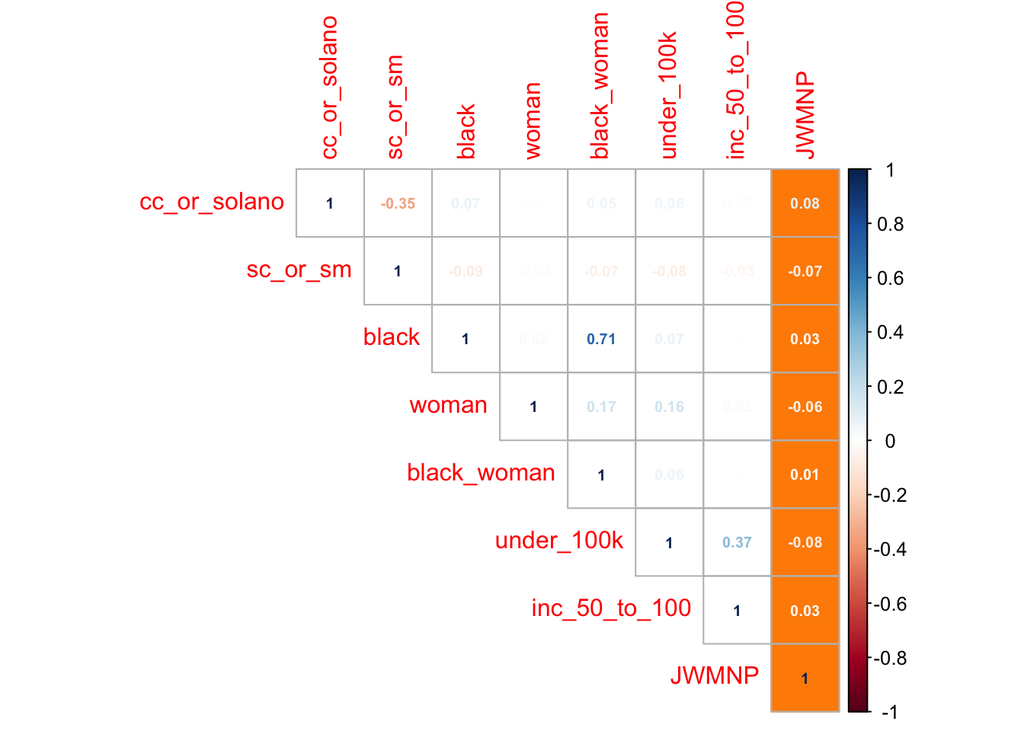

```r
pums_corr_plot <-
  bay_pums_tt_2018 %>%
  select(
    cc_or_solano,
    sc_or_sm,
    black,
    woman,
    black_woman,
    under_100k,
    inc_50_to_100,
    JWMNP
  ) %>%
  cor()

ColorScheme = c("white","darkorange")
Groups = c(rep(1, 28), rep(2, 8))

corrplot(
  pums_corr_plot,
  method = "number",
  type = "upper",
  bg=ColorScheme[Groups],
  number.cex= 5/ncol(pums_corr_plot)
)

segments(c(0.5,7.5,8.5), rep(0.5,1.5),
    c(0.5,7.5,8.5), rep(7.5,8.5), lwd=0)
```

INCOME The following plot depicts the relationship between income and travel to work times. Perhaps surprisingly as compared to the results of The Bay Area Equity Atlas, income and travel times appear to be positively correlated. This may seem counterintuitive given the knowledge that lower income workers are less likely to have access to private vehicles and the claim that they have less access to efficient public transport options. However, as suggested by this report https://www.ppic.org/wp-content/uploads/R_704LRR.pdf, lower income individuals may have less ability to take on jobs that are further away even if they are higher paying due to the transportation barrier. These results complicate the idea of longer travel times as reducing quality of life because there is certainly a case to be made that longer commutes pose personal costs in both time and money. However, the ability to embark on longer commutes may also open up opportunities for higher incomes, potentially increasing quality of life.

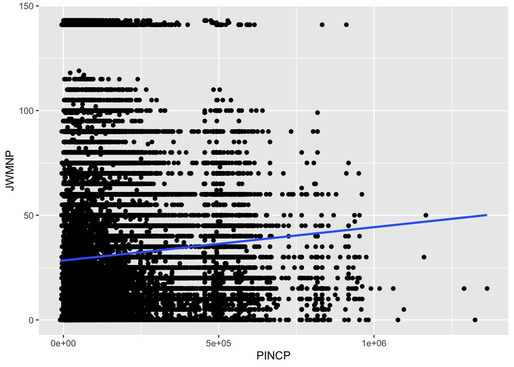

```r
ggplot(
  data = bay_pums_tt_2018,
  aes(
    x = PINCP,
    y = JWMNP
  )
) +
  geom_point() +
  geom_smooth(method = "lm", se = F)
```

RACE Results at the tract level point towards a relationship between the percentage of Black workers and the percentage of extreme commute times. The following multiple variable analysis investigates the relationship between both earning more than 50k and identifying as Black with commute times on an individual level. As previous results have indicated, those who earn more may have slightly higher commute times. What the “black” coefficient suggests is that even when controlling for having an income over 50k, workers who are black have on average commute times that are 4 minutes longer. This supports earlier results that point to race as being associated with longer incomes, even independent of income. As has been discussed, this finding is problematic.

```r
model_pums_tt_black <- lm(JWMNP ~ black + over_50k, bay_pums_tt_2018, weights = PWGTP)

summary(model_pums_tt_black)
```

```
##
## Call:
## lm(formula = JWMNP ~ black + over_50k, data = bay_pums_tt_2018,
##     weights = PWGTP)
##
## Weighted Residuals:
##     Min      1Q  Median      3Q     Max
## -375.75  -67.19  -23.80   45.08 1273.63
##
## Coefficients:
##             Estimate Std. Error t value Pr(>|t|)
## (Intercept) 26.79755    0.08275  323.82   <2e-16 ***
## black        4.17766    0.23394   17.86   <2e-16 ***
## over_50k     5.18816    0.11325   45.81   <2e-16 ***
## ---
## Signif. codes:  0 '***' 0.001 '**' 0.01 '*' 0.05 '.' 0.1 ' ' 1
##
## Residual standard error: 110 on 183021 degrees of freedom
## Multiple R-squared:  0.01252,    Adjusted R-squared:  0.0125
## F-statistic:  1160 on 2 and 183021 DF,  p-value: < 2.2e-16
```

These four results support the claims made by the Bay Area Equity Atlas. However, their R-squared numbers indicae that the variables in all of these results explain less than two percent of variation in travel to work times, suggesting the need to explore further variables to provide a more complete picture.

```r
model_pums_multiple_san_mateo <- lm(JWMNP ~ black + under_100k + woman + san_mateo, bay_pums_tt_2018, weights = PWGTP)
summary(model_pums_multiple_san_mateo)
```

```
##
## Call:
## lm(formula = JWMNP ~ black + under_100k + woman + san_mateo,
##     data = bay_pums_tt_2018, weights = PWGTP)
##
## Weighted Residuals:
##     Min      1Q  Median      3Q     Max
## -367.75  -67.55  -22.21   45.97 1242.71
##
## Coefficients:
##             Estimate Std. Error t value Pr(>|t|)
## (Intercept)  33.9606     0.1184  286.91   <2e-16 ***
## black         3.9703     0.2344   16.94   <2e-16 ***
## under_100k   -4.2847     0.1297  -33.04   <2e-16 ***
## woman        -2.3643     0.1147  -20.62   <2e-16 ***
## san_mateo    -2.5767     0.1838  -14.02   <2e-16 ***
## ---
## Signif. codes:  0 '***' 0.001 '**' 0.01 '*' 0.05 '.' 0.1 ' ' 1
##
## Residual standard error: 110.1 on 183019 degrees of freedom
## Multiple R-squared:  0.01168,    Adjusted R-squared:  0.01166
## F-statistic: 540.8 on 4 and 183019 DF,  p-value: < 2.2e-16
```

```r
model_pums_multiple_santa_clara <- lm(JWMNP ~ black + under_100k + woman + santa_clara, bay_pums_tt_2018, weights = PWGTP)
summary(model_pums_multiple_santa_clara)
```

```
##
## Call:
## lm(formula = JWMNP ~ black + under_100k + woman + santa_clara,
##     data = bay_pums_tt_2018, weights = PWGTP)
##
## Weighted Residuals:
##     Min      1Q  Median      3Q     Max
## -372.64  -67.39  -21.27   45.69 1238.74
##
## Coefficients:
##             Estimate Std. Error t value Pr(>|t|)
## (Intercept)  34.7636     0.1229  282.84   <2e-16 ***
## black         3.6710     0.2344   15.66   <2e-16 ***
## under_100k   -4.4451     0.1297  -34.28   <2e-16 ***
## woman        -2.4352     0.1145  -21.26   <2e-16 ***
## santa_clara  -3.6083     0.1307  -27.62   <2e-16 ***
## ---
## Signif. codes:  0 '***' 0.001 '**' 0.01 '*' 0.05 '.' 0.1 ' ' 1
##
## Residual standard error: 109.9 on 183019 degrees of freedom
## Multiple R-squared:  0.01473,    Adjusted R-squared:  0.0147
## F-statistic: 683.8 on 4 and 183019 DF,  p-value: < 2.2e-16
```

```r
model_pums_multiple_solano <- lm(JWMNP ~ black + under_100k + woman + solano, bay_pums_tt_2018, weights = PWGTP)
summary(model_pums_multiple_solano)
```

```
##
## Call:
## lm(formula = JWMNP ~ black + under_100k + woman + solano, data = bay_pums_tt_2018,
##     weights = PWGTP)
##
## Weighted Residuals:
##     Min      1Q  Median      3Q     Max
## -364.35  -67.62  -22.76   45.58 1247.21
##
## Coefficients:
##             Estimate Std. Error t value Pr(>|t|)
## (Intercept)  33.6042     0.1166 288.091   <2e-16 ***
## black         3.9752     0.2348  16.928   <2e-16 ***
## under_100k   -4.3221     0.1300 -33.258   <2e-16 ***
## woman        -2.3763     0.1147 -20.715   <2e-16 ***
## solano        2.2433     0.2567   8.739   <2e-16 ***
## ---
## Signif. codes:  0 '***' 0.001 '**' 0.01 '*' 0.05 '.' 0.1 ' ' 1
##
## Residual standard error: 110.1 on 183019 degrees of freedom
## Multiple R-squared:  0.01103,    Adjusted R-squared:  0.01101
## F-statistic: 510.4 on 4 and 183019 DF,  p-value: < 2.2e-16
```

```r
model_pums_multiple_contra_costa <- lm(JWMNP ~ black + under_100k + woman + contra_costa, bay_pums_tt_2018, weights = PWGTP)
summary(model_pums_multiple_contra_costa)
```

```
##
## Call:
## lm(formula = JWMNP ~ black + under_100k + woman + contra_costa,
##     data = bay_pums_tt_2018, weights = PWGTP)
##
## Weighted Residuals:
##     Min      1Q  Median      3Q     Max
## -408.68  -66.64  -21.95   45.99 1238.71
##
## Coefficients:
##              Estimate Std. Error t value Pr(>|t|)
## (Intercept)   32.8520     0.1176  279.29   <2e-16 ***
## black          3.6532     0.2335   15.65   <2e-16 ***
## under_100k    -4.3705     0.1292  -33.83   <2e-16 ***
## woman         -2.3941     0.1142  -20.96   <2e-16 ***
## contra_costa   6.6569     0.1625   40.97   <2e-16 ***
## ---
## Signif. codes:  0 '***' 0.001 '**' 0.01 '*' 0.05 '.' 0.1 ' ' 1
##
## Residual standard error: 109.6 on 183019 degrees of freedom
## Multiple R-squared:  0.01961,    Adjusted R-squared:  0.01959
## F-statistic: 915.3 on 4 and 183019 DF,  p-value: < 2.2e-16
```

```r
years <- 2009:2019
year <- NULL
perc_ext_nonblack <- NULL
perc_ext_black <- NULL
tt_black <- NULL
tt_nonblack <- NULL

for(yr in years) {
  if(yr >= 2017) {
    yearly_pums_vars <-
      pums_variables %>%
      filter(year == yr, survey == "acs1")
    fileToRead <-
      paste0(
        yr,
        "ca_pums.rds"
      )
    yearly_ca_pums <-
      readRDS(fileToRead)
  } else {
    filepath <- "/Users/megsaunders/Documents/GitHub/218X/"
    filename <-
      paste0(
        filepath,
        "ss",
        str_sub(toString(yr), start= -2),
        "pca.csv"
      )
    yearly_ca_pums <-
      read_csv(filename) %>%
      select(
        PUMA,
        JWMNP,
        RACBLK,
        ESR,
        PWGTP
      )
  }

  yearly_bay_pums <-
      yearly_ca_pums %>%
      filter(PUMA %in% bay_pumas$PUMACE10)

  yearly_extreme_pums <-
    yearly_bay_pums %>%
    filter(!is.na(JWMNP)) %>%
    filter(ESR == 1) %>% #filters to working persons only
    mutate(
      extreme = ifelse(
        as.numeric(JWMNP) >= 90,
        1,
        0
      ),
      black = ifelse(
        as.numeric(RACBLK) == 1,
        1,
        0
      )
    )

  model_yearly_extreme_black <-
    lm(extreme ~ black, yearly_extreme_pums, weights = as.numeric(PWGTP))

  model_yearly_tt_black <-
    lm(JWMNP ~ black, yearly_extreme_pums, weights = as.numeric(PWGTP))

  year <- append(year, yr)
  tt_black <- append(tt_black, model_yearly_tt_black$coefficients[1])
  tt_nonblack <- append(tt_nonblack, model_yearly_tt_black$coefficients[1] + model_yearly_tt_black$coefficients[2])
  perc_ext_nonblack <- append(perc_ext_nonblack, model_yearly_extreme_black$coefficients[1]*100)
  perc_ext_black <- append(perc_ext_black, (model_yearly_extreme_black$coefficients[1] + model_yearly_extreme_black$coefficients[2])*100)
}

timescale_extreme_black <- data.frame(year, perc_ext_nonblack, perc_ext_black, tt_nonblack, tt_black)
```

The following two charts illustrate the change in percentages of extreme commutes and the change in average travel times to work over the decade between 2009 and 2019 in order to provide further insight into findings on the association between the race of workers and their commute times. The first chart shows two regression lines changing over time: the first uses the Intercept coefficient for the percentage of employed individuals with extreme travel commutes. This line is labeled Non-Black Workers because it represents the average percentage of extreme commutes for Non-Black workers. The second line uses the sum of the Intercept coefficient and the perc_ext_black coefficient and is labeled “Black Workers” because it takes into account the increase in the likelihood of an individual having an extreme commute time if they are a black worker. The second chart is structured similarly but it shows the average commute times rather than the likelihood of extreme commute times.

The results of this perspective are concerning, and support the claims made by the article. Firstly, the charts indicate that commute times in general and the percentage of workers with extreme commutes has increased over the past decade. Secondly, it indicates that the disparity of these outcomes for Black and Non-Black workers has increased in the past decade, having increased at a faster rate for Black workers particularly between the years 2009 and 2012, which is problematic from a racial equity perspective. The increase has remained more or less equal from around 2013-2018, although the fact that it is increasing for both groups is not a good thing either from the perspective of diminished quality of life for residents of the bay area. Further, the second chart suggests that gaps in commute times for Black and Nonblack workers have started to widening more since 2018.

In sum, the tragectory of these timescale analysis suggests that without intervention, the problems of increasing commute times, and racial disparities in commute times will get worse.

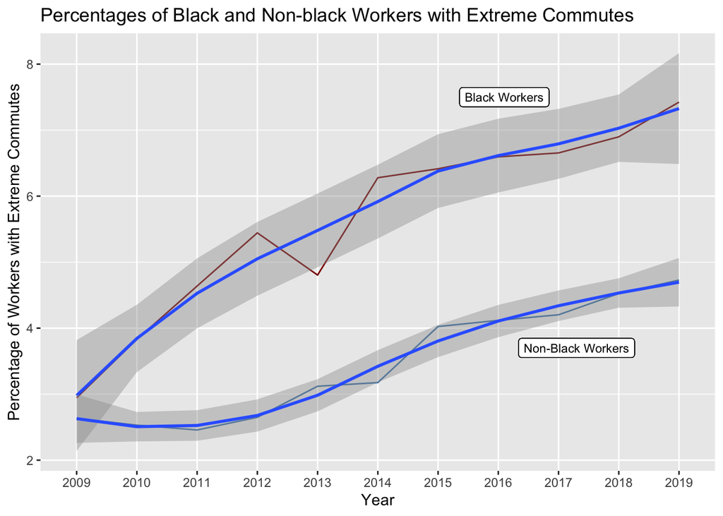

```r
timescale_extreme_black %>%
  ggplot(
    aes(
      x = year %>% factor(),
      group = 1
      #y = perc_ext_black,
      #y = perc_ext_nonblack
    )) +
  geom_line(aes(y = perc_ext_black), color = "darkred") +
  geom_line(aes(y = perc_ext_nonblack), color = "steelblue") +
  geom_label(aes(x = 9.3, y = 3.7, label = "Non-Black Workers"), size = 3) +
  geom_label(aes(x = 8.1, y = 7.5, label = "Black Workers"), size = 3) +
  geom_smooth(aes(y = perc_ext_black)) +
  geom_smooth(aes(y = perc_ext_nonblack)) +
  labs(
    x = "Year",
    y = "Percentage of Workers with Extreme Commutes",
    title = "Percentages of Black and Non-black Workers with Extreme Commutes"
  )
```

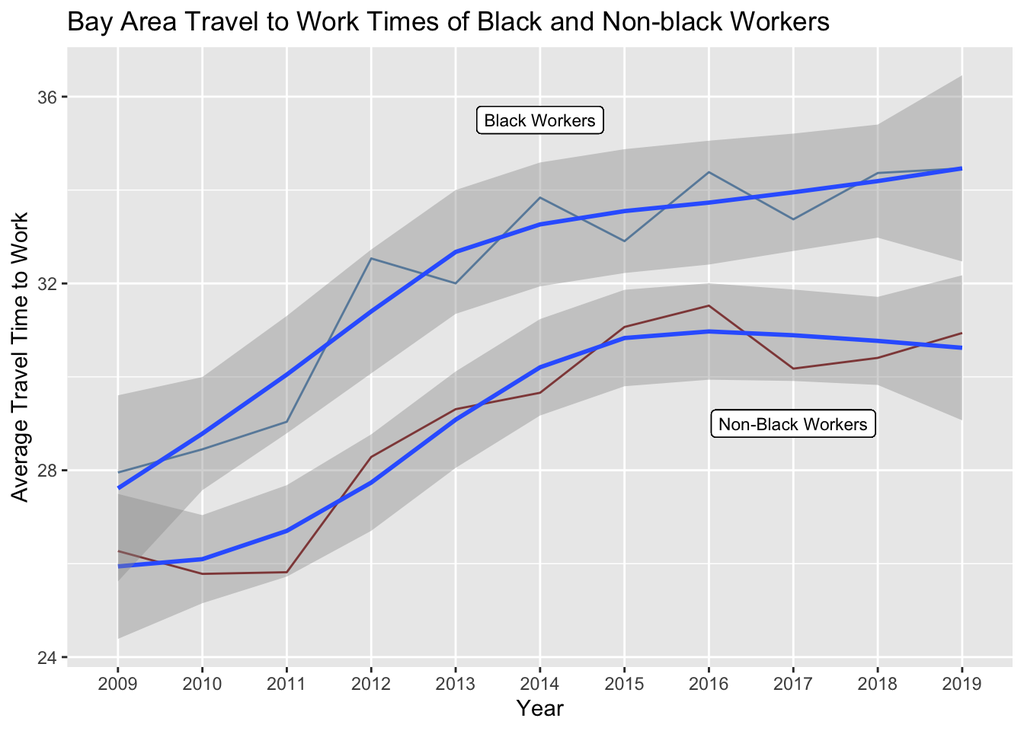

```r
timescale_extreme_black %>%
  ggplot(
    aes(
      x = year %>% factor(),
      group = 1
      #y = perc_ext_black,
      #y = perc_ext_nonblack
    )) +
  geom_line(aes(y = tt_black), color = "darkred") +
  geom_line(aes(y = tt_nonblack), color = "steelblue") +
  geom_label(aes(x = 9.0, y = 29, label = "Non-Black Workers"), size = 3) +
  geom_label(aes(x = 6.0, y = 35.5, label = "Black Workers"), size = 3) +
  geom_smooth(aes(y = tt_black)) +
  geom_smooth(aes(y = tt_nonblack)) +
  labs(
    x = "Year",
    y = "Average Travel Time to Work",
    title = "Bay Area Travel to Work Times of Black and Non-black Workers"
  )
```